# p8105_hw4_gk2501

Gaeun Kim

10/27/2017

## Problem 2

Partners whould switch roles: the former “project lead” will be the “collaborator”, and the former “collaborator” will be the “project lead”. The project lead should:

create a directory put an R project in the directory initialize Git add the collaborator as a collaborator on GitHub start an R Markdown file for this problem This problem uses the 538 datasets. Because this dataset is small and can be made public you should include that data file in your directory for this problem, and load that data file using relative paths.

The project lead will load and tidy the data for this problem. Combine the data in pols-month.csv and GDP.csv based on the date / month (use lubridate::floor_date to collase dates to the first day of the month).

The collaborator will create a plot showing the GDP value over time, including the party of the president in an informative aesthetic.

The R Markdown document in your GitHub repository should produce a file including code and text that explains the analyses and results for this problem.

```r
library(tidyverse)
library(readxl)
library(janitor)
```

```r
pols = read_csv("./data/pols-month.csv") %>%
  clean_names() %>%
  mutate(mon =
  lubridate::floor_date(mon, c("month")), date = mon
  ) %>%
  select(date, everything(), -mon)
gdp = read_csv("./data/GDP.csv") %>%
  clean_names() %>%
  mutate(date =
  lubridate::floor_date(date, c("month"))
  ) %>%
  mutate(gdp = value) %>%
  select(-value)
```

I have read and cleaned both the pols data and gdp data. Also, I have changed their mon/date variable to have the same name and be both dates to the first day of the month. Next, I will join the two datasets by date.

```r
pols_gdp = left_join(pols, gdp, by = "date") %>%
  group_by(date) %>%
  summarise(gdp_month = mean(as.numeric(gdp), na.rm = TRUE),
            prez_party = ifelse(prez_gop > 0, "republican", "democratic")) %>%
  na.omit()
```

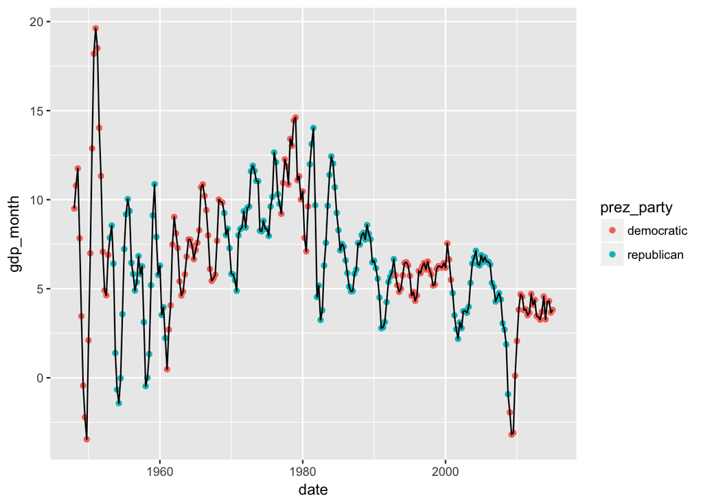

```r
pols_gdp %>%
  ggplot(aes(x = date, y = gdp_month)) +
  geom_point(aes(color = prez_party)) +
  geom_line()
```